# Transformation to near Normality of Multivariate Data Using R

March 17, 2015

### Problem 4.27:

Consider the radiation data in Example 4.10.

Construct a Q-Q plot for the natural logarithms of these data. Do the natural logarithms appear to normally distributed?

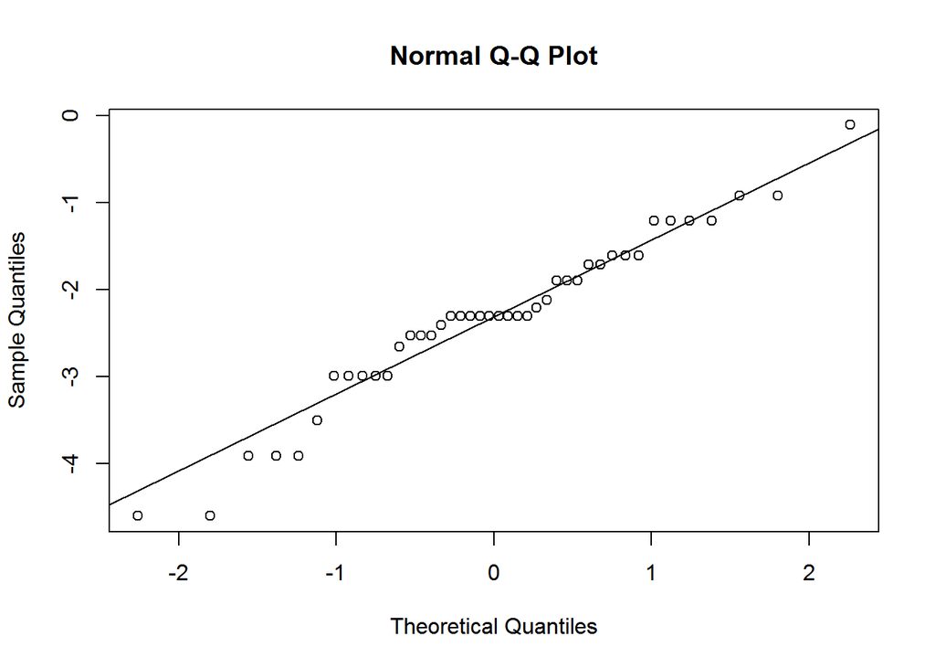

```r
# create a data matrix
radiation <- matrix(c(0.15,0.9,0.18,0.1,0.05,0.12,0.08,0.05,0.08,0.1,0.07,0.02,0.01,0.1,0.1,0.1,0.02,0.1,0.01,0.4,0.1,0.05,0.03,0.05,0.15,0.1,0.15,0.09,0.08,0.18,0.1,0.2,0.11,0.3,0.02,0.2,0.2,0.3,0.3,0.4,0.3,0.05))

colnames(radiation) <-c("Radiation")

# construct a q-q plot
qqnorm(log(radiation))
qqline(log(radiation))
```

```r
# compute the marginal normality
shapiro.test(log(radiation))
```

```
##
##  Shapiro-Wilk normality test
##
## data:  log(radiation)
## W = 0.9615, p-value = 0.1665
```

The Q-Q plot appears to be straight, hence the data are normally distributed. In addition, the test of normality produces a p-value of 0.1665 showing that the data is normally distributed.

### Problem 4.29

Given the air pollution data.

```r
# read the data into R
pollution_data <- read.table("table15.txt")

# examine columns five and six
data2 <- (pollution_data[,5:6])
colnames(data2) <- c("NO2", "O3")

# calcualate the sample mean vector
cm <- colMeans(data2)
cm
```

```
##       NO2        O3
## 10.047619  9.404762
```

```r
# calculate the variance-covariance Matrix
S <- cov(data2)
S
```

```
##           NO2        O3
## NO2 11.363531  3.126597
## O3   3.126597 30.978513
```

```r
# calaculate the statistical square distances
d <- apply(data2, MARGIN = 1, function(data2) +
                   t(data2-cm) %*% solve(S) %*% (data2-cm))
d
```

```
##  [1]  0.4606524  0.6592206  2.3770610  1.6282902  0.4135364  0.4760726
##  [7]  1.1848895 10.6391792  0.1388339  0.8162468  1.3566301  0.6228096
## [13]  5.6494392  0.3159498  0.4135364  0.1224973  0.8987982  4.7646873
## [19]  3.0089122  0.6592206  2.7741416  1.0360061  0.7874152  3.4437748
## [25]  6.1488606  1.0360061  0.1388339  0.8856041  0.1379719  2.2488867
## [31]  0.1901188  0.4606524  1.1471939  7.0857237  1.4584229  0.1224973
## [37]  1.8984708  2.7782596  8.4730649  0.6370218  0.7032485  1.8013611
```

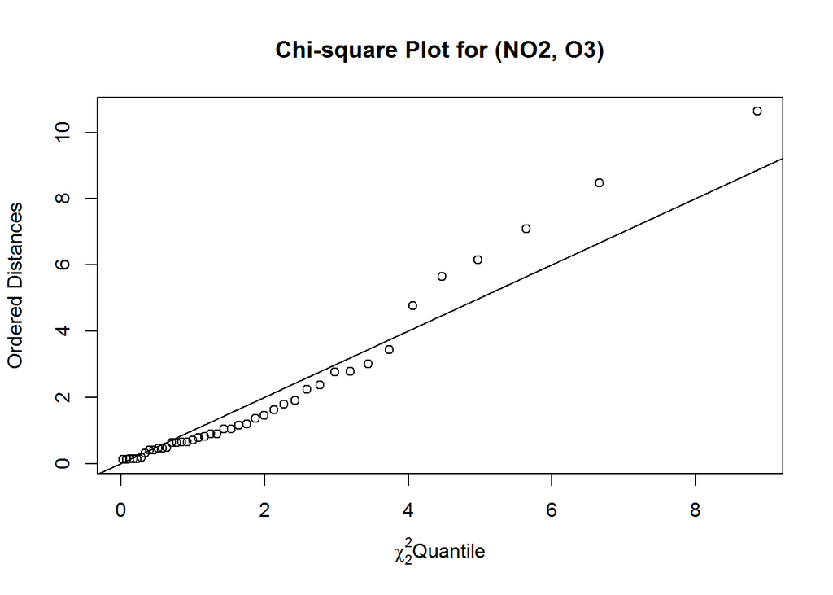

```r
# construct a chi-square plot of the ordered distances
par(mfrow = c(1,1))
plot(qchisq((1:nrow(data2)-1/2)/nrow(data2),df=2), sort(d),
     xlab = expression(paste(chi[2]^2, "Quantile")),
     ylab = "Ordered Distances",
     main = "Chi-square Plot for (NO2, O3)"); abline(a=0, b=1)
```

The number of units = 26 The proportion = 62%

### Problem 4.33

## (a)

Examine the margninal normality of the observations for the data in Table 4.3.

```r
# read the data into R
data3 <- read.table("table43.txt")
colnames(data3)<-c("X1", "X2", "X3", "X4","X5")
library(MVN)
uniNorm(data3, type = "SW", desc = TRUE)
```

```
## $`Descriptive Statistics`
##     n     Mean Std.Dev  Median     Min     Max     25th     75th  Skew
## X1 30 1906.100 324.987 1863.00 1325.00 2983.00 1715.250 2057.250 1.038
## X2 30 1749.533 318.607 1680.00 1170.00 2794.00 1595.500 1888.750 1.144
## X3 30 1509.133 303.178 1466.00 1002.00 2412.00 1295.750 1623.750 0.980
## X4 30 1724.967 322.844 1674.50 1176.00 2581.00 1520.250 1880.750 0.598
## X5 30    3.867   3.734    2.64    0.13   16.85    1.415    5.043 1.786
##    Kurtosis
## X1    2.036
## X2    1.950
## X3    0.997
## X4   -0.046
## X5    3.140
##
## $`Shapiro-Wilk's Normality Test`
##    Variable Statistic   p-value Normality
## 1    X1        0.9307    0.0512    YES
## 2    X2        0.9127    0.0175    NO
## 3    X3        0.9326    0.0575    YES
## 4    X4        0.9613    0.3337    YES
## 5    X5        0.7999    0.0001    NO
```

## (b)

Examine the bivariate normality of the observations for the data.

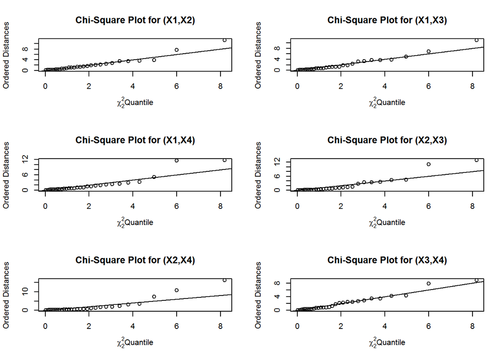

```r
# examine columns one upto four
data3 <- (data3[,-5])

# construct the bivariate chi-square plot for X1 and X2
data3_X1x2 <- (data3[,c("X1","X2")])
cm3_X1X2 <- colMeans(data3_X1x2)
S3_X1X2 <- cov(data3_X1x2)
d3_X1X2 <- apply(data3_X1x2, MARGIN = 1, function(data3_X1x2) +
                   t(data3_X1x2-cm3_X1X2) %*% solve(S3_X1X2) %*% (data3_X1x2-cm3_X1X2))

par(mfrow = c(3,2))
plot(qchisq((1:nrow(data3_X1x2)-1/2)/nrow(data3_X1x2),df=2), sort(d3_X1X2),
     xlab = expression(paste(chi[2]^2, "Quantile")),
     ylab = "Ordered Distances",
     main = "Chi-Square Plot for (X1,X2)"); abline(a=0, b=1)

# construct the bivariate chi-square plot for X1 and X3
data3_X1x3 <- (data3[,c("X1","X3")])
cm3_X1X3 <- colMeans(data3_X1x3)
S3_X1X3 <- cov(data3_X1x3)
d3_X1X3 <- apply(data3_X1x3, MARGIN = 1, function(data3_X1x3) +
                   t(data3_X1x3-cm3_X1X3) %*% solve(S3_X1X3) %*% (data3_X1x3-cm3_X1X3))

plot(qchisq((1:nrow(data3_X1x3)-1/2)/nrow(data3_X1x3),df=2), sort(d3_X1X3),
     xlab = expression(paste(chi[2]^2, "Quantile")),
     ylab = "Ordered Distances",
     main = "Chi-Square Plot for (X1,X3)"); abline(a=0, b=1)

# construct the bivariate chi-square plot for X1 and X4
data3_X1x4 <- (data3[,c("X1","X4")])
cm3_X1X4 <- colMeans(data3_X1x4)
S3_X1X4 <- cov(data3_X1x4)
d3_X1X4 <- apply(data3_X1x4, MARGIN = 1, function(data3_X1x4) +
                   t(data3_X1x4-cm3_X1X4) %*% solve(S3_X1X4) %*% (data3_X1x4-cm3_X1X4))

plot(qchisq((1:nrow(data3_X1x4)-1/2)/nrow(data3_X1x4),df=2), sort(d3_X1X4),
     xlab = expression(paste(chi[2]^2, "Quantile")),
     ylab = "Ordered Distances",
     main = "Chi-Square Plot for (X1,X4)"); abline(a=0, b=1)

# construct the bivariate chi-square plot for X2 and X3
data3_X2x3 <- (data3[,c("X2","X3")])
cm3_X2x3 <- colMeans(data3_X2x3)
S3_X2x3 <- cov(data3_X2x3)
d3_X2x3 <- apply(data3_X2x3, MARGIN = 1, function(data3_X2x3) +
                   t(data3_X2x3-cm3_X2x3) %*% solve(S3_X2x3) %*% (data3_X2x3-cm3_X2x3))


plot(qchisq((1:nrow(data3_X2x3)-1/2)/nrow(data3_X2x3),df=2), sort(d3_X2x3),
     xlab = expression(paste(chi[2]^2, "Quantile")),
     ylab = "Ordered Distances",
     main = "Chi-Square Plot for (X2,X3)"); abline(a=0, b=1)

# construct the bivariate chi-square plot for X2 and X4
data3_X2x4 <- (data3[,c("X2","X4")])
cm3_X2x4 <- colMeans(data3_X2x4)
S3_X2x4 <- cov(data3_X2x4)
d3_X2x4 <- apply(data3_X2x4, MARGIN = 1, function(data3_X2x4) +
                   t(data3_X2x4-cm3_X2x4) %*% solve(S3_X2x4) %*% (data3_X2x4-cm3_X2x4))


plot(qchisq((1:nrow(data3_X2x4)-1/2)/nrow(data3_X2x4),df=2), sort(d3_X2x4),
     xlab = expression(paste(chi[2]^2, "Quantile")),
     ylab = "Ordered Distances",
     main = "Chi-Square Plot for (X2,X4)"); abline(a=0, b=1)

# construct the bivariate chi-square plot for X3 and X4
data3_X3x4 <- (data3[,c("X3","X4")])
cm3_X3x4 <- colMeans(data3_X3x4)
S3_X3x4 <- cov(data3_X3x4)
d3_X3x4 <- apply(data3_X3x4, MARGIN = 1, function(data3_X3x4) +
                   t(data3_X3x4-cm3_X3x4) %*% solve(S3_X3x4) %*% (data3_X3x4-cm3_X3x4))


plot(qchisq((1:nrow(data3_X3x4)-1/2)/nrow(data3_X3x4),df=2), sort(d3_X3x4),
     xlab = expression(paste(chi[2]^2, "Quantile")),
     ylab = "Ordered Distances",
     main = "Chi-Square Plot for (X3,X4)"); abline(a=0, b=1)
```

The chi-square plots for (x1,x2), (x1,x3), and (x3,x4) are straight lines while (x1,x4), (x2,x3) and (x2,x4) do not appear to be straight.

### Problem 4.39

## (a)

Using the data in Table 4.6, examine each of the variables independence, support, benevolence, conformity, and leadership for marginal normality.

```r
# read the data into R
data4 <- read.table("table46.txt")

# examine columns one upto five
data4 <- (data4[,1:5])
colnames(data4) <- c("independence", "support", "benevolence", "conformity", "leadership")

# test the marginal normality for each variable
uniNorm(data4, type = "SW", desc = TRUE)
```

```
## $`Descriptive Statistics`
##                n   Mean Std.Dev Median Min Max  25th 75th   Skew Kurtosis
## independence 130 15.669   5.895     15   3  31 11.25   19  0.427   -0.371
## support      130 17.077   4.185     18   6  27 14.00   20 -0.310   -0.429
## benevolence  130 18.785   5.463     19   2  29 15.00   22 -0.299   -0.215
## conformity   130 15.500   5.748     16   1  27 11.25   19 -0.161   -0.628
## leadership   130 11.731   5.192     11   2  29  8.00   15  0.669    0.124
##
## $`Shapiro-Wilk's Normality Test`
##       Variable Statistic   p-value Normality
## 1 independence    0.9749    0.0162    NO
## 2   support       0.9779    0.0320    NO
## 3 benevolence     0.9839    0.1269    YES
## 4  conformity     0.9846    0.1500    YES
## 5  leadership     0.9626    0.0012    NO
```

Only two variables are normaly distributed, that is, benevolence and conformity.

## (b)

Using all five variables, check for multivariate normality

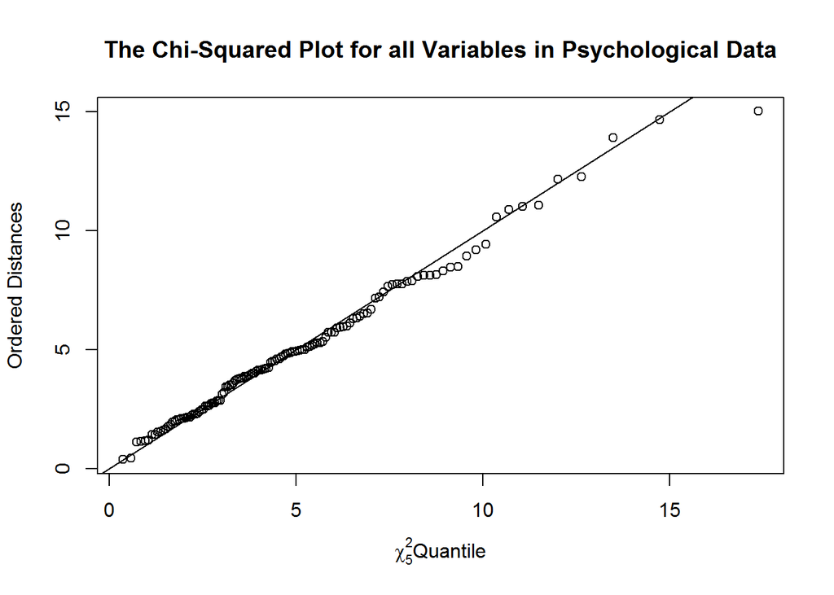

```r
# calculate the sample mean vector
cm4 <- colMeans(data4)

# calculate the variance-covariance Matrix
S4 <- cov(data4)

# calaculate the statistical square distances
d4 <- apply(data4, MARGIN = 1, function(data4) +
                   t(data4-cm4) %*% solve(S4) %*% (data4-cm4))

# construct the chi-square plots
plot(qchisq((1:nrow(data4)-1/2)/nrow(data4),df=5), sort(d4),
     xlab = expression(paste(chi[5]^2, "Quantile")),
     ylab = "Ordered Distances",
     main = "The Chi-Squared Plot for all Variables in Psychological Data"); abline(a=0, b=1)
```

## (c)

For those variables that are not normal, determine the transformation that makes them nearly normal

```r
# take the square root of the variables independence and leadership
data4$independence <- sqrt(data4$independence)
data4$leadership <- sqrt(data4$leadership)

# take the natural log of variable support
data4$support <- log(data4$support)

# test for normality
uniNorm(data4, type = "SW", desc = TRUE)
```

```
## $`Descriptive Statistics`
##                n   Mean Std.Dev Median   Min    Max   25th   75th   Skew
## independence 130  3.886   0.755  3.873 1.732  5.568  3.353  4.359 -0.041
## support      130  2.803   0.276  2.890 1.792  3.296  2.639  2.996 -1.018
## benevolence  130 18.785   5.463 19.000 2.000 29.000 15.000 22.000 -0.299
## conformity   130 15.500   5.748 16.000 1.000 27.000 11.250 19.000 -0.161
## leadership   130  3.341   0.758  3.317 1.414  5.385  2.828  3.873  0.126
##              Kurtosis
## independence   -0.316
## support         1.087
## benevolence    -0.215
## conformity     -0.628
## leadership     -0.344
##
## $`Shapiro-Wilk's Normality Test`
##       Variable Statistic   p-value Normality
## 1 independence    0.9891    0.3944    YES
## 2   support       0.9264    0.0000    NO
## 3 benevolence     0.9839    0.1269    YES
## 4  conformity     0.9846    0.1500    YES
## 5  leadership     0.9914    0.6053    YES
```

Now all the variables are normaly distributed except for support.

### Problem 4.41

Consider the data on snow removal.

## (a)

Comment on any outliers in a scatter plot of the original variables

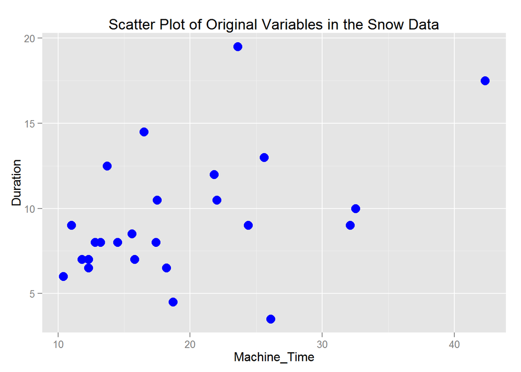

```r
# read the data into R
data5 <- read.table("table32.txt")
colnames(data5) <- c("Duration", "Machine_Time")

# scatter plot of the data
library(ggplot2)
ggplot(data5, aes(Machine_Time, Duration)) + geom_point(color = "blue", size = 4) + ggtitle ("Scatter Plot of Original Variables in the Snow Data")
```

There appears to be one outlier at position (42.3, 17.5)

## (b)

Determine the power transformation that makes “Duration” approximately normal. Construct a QQ plot of the transformed observations

```r
# first check for normality before transformation
shapiro.test(data5$Duration)
```

```
##
##  Shapiro-Wilk normality test
##
## data:  data5$Duration
## W = 0.917, p-value = 0.04382
```

```r
# transform by taking the natural log of Duration i.e (lambda = 0)
shapiro.test(log(data5$Duration))
```

```
##
##  Shapiro-Wilk normality test
##
## data:  log(data5$Duration)
## W = 0.9779, p-value = 0.8416
```

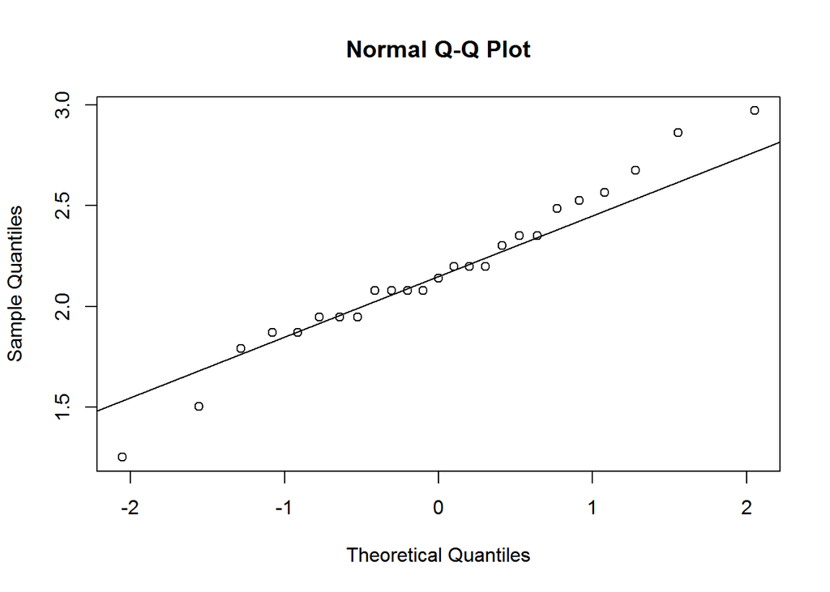

```r
# construct a QQ plot of the transformed Duration observations
qqnorm(log(data5$Duration))
qqline(log(data5$Duration))
```

## (c)

Determine the power transformation that makes “Machine_Time” approximately normal. Construct a QQ plot of the transformed observations

```r
# first check for normality before transformation
shapiro.test(data5$Machine_Time)
```

```
##
##  Shapiro-Wilk normality test
##
## data:  data5$Machine_Time
## W = 0.8819, p-value = 0.00755
```

```r
# transform by taking the natural log of Machine_Time data i.e (lambda = 0)
shapiro.test(log(data5$Machine_Time))
```

```
##
##  Shapiro-Wilk normality test
##
## data:  log(data5$Machine_Time)
## W = 0.9589, p-value = 0.3921
```

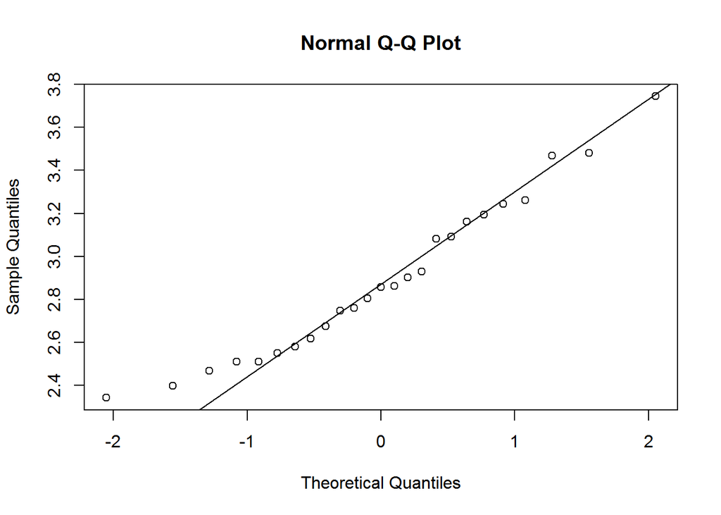

```r
# construct a QQ plot of the transformed Machine_Time data
qqnorm(log(data5$Machine_Time))
qqline(log(data5$Machine_Time))
```

## (d)

Determine the power transformation for approximate bivariate normality using (4-40)

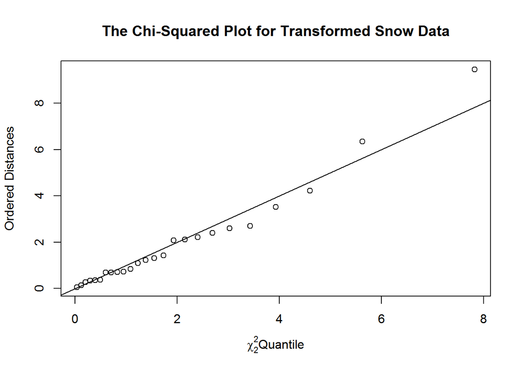

```r
# calculate the sample mean vector
data5 <- log(data5)
cm5 <- colMeans(data5)

# calculate the variance-covariance Matrix
S5 <- cov(data5)

# calaculate the statistical square distances
d5 <- apply(data5, MARGIN = 1, function(data5) +
                   t(data5-cm5) %*% solve(S5) %*% (data5-cm5))

# construct the chi-square plots
plot(qchisq((1:nrow(data5)-1/2)/nrow(data5),df=2), sort(d5),
     xlab = expression(paste(chi[2]^2, "Quantile")),
     ylab = "Ordered Distances",
     main = "The Chi-Squared Plot for Transformed Snow Data"); abline(a=0, b=1)
```